# Tipología: PRA2 - Limpieza y validación de los datos

Autor: Violeta Andrade

Junio 2019

# 1 Introducción y carga de datos

A la muestra aleatoria se le llamó MUESTRA_LOAN y es la base con la que trabajaremos en esta práctica.

```r
# Cargaremos la muestra de la base
data <- read.csv('MUESTRA_LOAN.csv',stringsAsFactors = FALSE)
# Desplegamos las columnas de data
colnames(data)
```

```
##  [1] "monto_prestamo"         "plazo"
##  [3] "tasa_interes"           "trabajo_prestatario"
##  [5] "antiguedad_prestatario" "estatus_vivienda"
##  [7] "ingreso_anual"          "estatus_verif_ingreso"
##  [9] "fecha_prestamo"         "estatus_prestamo"
## [11] "tipo_prestamo"          "estado_vive"
## [13] "proporcion_pagos"       "pagos_recib"
## [15] "cargos_atrasados"       "pagos_mes_anterior"
## [17] "meses_mala_calif"       "tipo_solicitud"
## [19] "ingreso_conjunto"       "cuentas_mora"
## [21] "saldo_total"            "saldo_plazos"
## [23] "hipotecas"              "metodo_recibe_pago"
```

Ahora podemos ver que eliminamos los dos id que contenía la base original, esto se hizo porque ambos venian completamente vacíos. Por esta razón añadiremos un consecutivo que servirá como id para esta nueva base.

```r
# insertaremos un consecutivo en la base
data$id<-1:nrow(data)
```

A continuación veremos la forma de la base data

```r
str(data)
```

```
## 'data.frame':    10000 obs. of  25 variables:
##  $ monto_prestamo        : int  10450 14000 11500 11000 4800 5000 30000 35000 23000 32000 ...
##  $ plazo                 : chr  "36 months" "36 months" "36 months" "36 months" ...
##  $ tasa_interes          : num  18.94 14.47 8.19 6.46 18.94 ...
##  $ trabajo_prestatario   : chr  "Project Manager" "Rad tech" "President" "School Readiness Teacher" ...
##  $ antiguedad_prestatario: chr  "10+ years" "10+ years" "10+ years" "3 years" ...
##  $ estatus_vivienda      : chr  "MORTGAGE" "MORTGAGE" "MORTGAGE" "ANY" ...
##  $ ingreso_anual         : num  70000 36000 173370 45000 28000 ...
##  $ estatus_verif_ingreso : chr  "Source Verified" "Not Verified" "Not Verified" "Not Verified" ...
##  $ fecha_prestamo        : chr  "01-12-2018" "01-12-2018" "01-12-2018" "01-12-2018" ...
##  $ estatus_prestamo      : chr  "Current" "Current" "Current" "Current" ...
##  $ tipo_prestamo         : chr  "Debt consolidation" "Credit card refinancing" "Credit card refinancing" "Credit card refinancing" ...
##  $ estado_vive           : chr  "TN" "NE" "MN" "MN" ...
##  $ proporcion_pagos      : num  27.4 28.1 25.3 21.7 12.6 ...
##  $ pagos_recib           : num  377 946 374 668 316 ...
##  $ cargos_atrasados      : num  0 0 0 0 0 0 0 0 0 0 ...
##  $ pagos_mes_anterior    : chr  "01-02-2019" "01-02-2019" "01-02-2019" "01-02-2019" ...
##  $ meses_mala_calif      : int  NA 28 NA NA NA NA NA 46 NA NA ...
##  $ tipo_solicitud        : chr  "Individual" "Individual" "Individual" "Individual" ...
##  $ ingreso_conjunto      : num  NA NA NA NA NA NA 107000 NA NA NA ...
##  $ cuentas_mora          : int  0 0 0 0 0 0 0 0 0 0 ...
##  $ saldo_total           : int  410636 40699 509992 91997 9887 195476 219255 57866 16223 63815 ...
##  $ saldo_plazos          : int  6660 34579 46707 80176 0 37602 22255 21465 938 5233 ...
##  $ hipotecas             : int  1 0 2 0 0 1 4 2 0 3 ...
##  $ metodo_recibe_pago    : chr  "Cash" "Cash" "Cash" "DirectPay" ...
##  $ id                    : int  1 2 3 4 5 6 7 8 9 10 ...
```

Ahora comenzaremos con la exploración y la limpieza de los datos. Empezamos con identificar si es que existen valores nulos en alguna de las variables elegidas:

```r
colSums(is.na(data))
```

```
##         monto_prestamo                  plazo           tasa_interes
##                      0                      0                      0
##    trabajo_prestatario antiguedad_prestatario       estatus_vivienda
##                      0                      0                      0
##          ingreso_anual  estatus_verif_ingreso         fecha_prestamo
##                      0                      0                      0
##       estatus_prestamo          tipo_prestamo            estado_vive
##                      0                      0                      0
##       proporcion_pagos            pagos_recib       cargos_atrasados
##                      8                      0                      0
##     pagos_mes_anterior       meses_mala_calif         tipo_solicitud
##                      0                   7348                      0
##       ingreso_conjunto           cuentas_mora            saldo_total
##                   9423                      0                    281
##           saldo_plazos              hipotecas     metodo_recibe_pago
##                   3753                    190                      0
##                     id
##                      0
```

```r
colSums(data=="")
```

```
##         monto_prestamo                  plazo           tasa_interes
##                      0                      0                      0
##    trabajo_prestatario antiguedad_prestatario       estatus_vivienda
##                    765                      0                      0
##          ingreso_anual  estatus_verif_ingreso         fecha_prestamo
##                      0                      0                      0
##       estatus_prestamo          tipo_prestamo            estado_vive
##                      0                    123                      0
##       proporcion_pagos            pagos_recib       cargos_atrasados
##                     NA                      0                      0
##     pagos_mes_anterior       meses_mala_calif         tipo_solicitud
##                     11                     NA                      0
##       ingreso_conjunto           cuentas_mora            saldo_total
##                     NA                      0                     NA
##           saldo_plazos              hipotecas     metodo_recibe_pago
##                     NA                     NA                      0
##                     id
##                      0
```

Existen variables numéricas que tienen valores vacíos como: proporcion_pagos, meses_mala_calif, ingreso_conjunto, saldo_total, saldo_plazos e hipotecas. Llenaremos estos valores vacíos con 0 ya que parece la opción que más se ajusta a todos los atributos.

```r
data$proporcion_pagos[is.na(data$proporcion_pagos)] <-0
data$meses_mala_calif[is.na(data$meses_mala_calif)] <-0
data$ingreso_conjunto[is.na(data$ingreso_conjunto)] <-0
data$saldo_total[is.na(data$saldo_total)] <-0
data$saldo_plazos[is.na(data$saldo_plazos)] <-0
data$hipotecas[is.na(data$hipotecas)] <-0
```

También hay variables tipo char con valores vacíos como: trabajo_prestatario, tipo_prestamo y pagos_mes_anterior. Para el atributo trabajo_prestatario llenaremos los valores vacíos con “ND”, o no disponible. En el caso de tipo_prestamo eliminaremos los registros que tengan esta columna vacía, ya que es una de las variables más importantes y son muy pocos registros. Por último, también eliminaremos los registros con el atributo pagos_mes_anterior vacío.

```r
data$trabajo_prestatario[data$trabajo_prestatario==""]="ND"
data_2<-subset(data,tipo_prestamo!="")
data_fin<-subset(data_2,pagos_mes_anterior!="")
str(data_fin)
```

```
## 'data.frame':    9866 obs. of  25 variables:
##  $ monto_prestamo        : int  10450 14000 11500 11000 4800 5000 30000 35000 23000 32000 ...
##  $ plazo                 : chr  "36 months" "36 months" "36 months" "36 months" ...
##  $ tasa_interes          : num  18.94 14.47 8.19 6.46 18.94 ...
##  $ trabajo_prestatario   : chr  "Project Manager" "Rad tech" "President" "School Readiness Teacher" ...
##  $ antiguedad_prestatario: chr  "10+ years" "10+ years" "10+ years" "3 years" ...
##  $ estatus_vivienda      : chr  "MORTGAGE" "MORTGAGE" "MORTGAGE" "ANY" ...
##  $ ingreso_anual         : num  70000 36000 173370 45000 28000 ...
##  $ estatus_verif_ingreso : chr  "Source Verified" "Not Verified" "Not Verified" "Not Verified" ...
##  $ fecha_prestamo        : chr  "01-12-2018" "01-12-2018" "01-12-2018" "01-12-2018" ...
##  $ estatus_prestamo      : chr  "Current" "Current" "Current" "Current" ...
##  $ tipo_prestamo         : chr  "Debt consolidation" "Credit card refinancing" "Credit card refinancing" "Credit card refinancing" ...
##  $ estado_vive           : chr  "TN" "NE" "MN" "MN" ...
##  $ proporcion_pagos      : num  27.4 28.1 25.3 21.7 12.6 ...
##  $ pagos_recib           : num  377 946 374 668 316 ...
##  $ cargos_atrasados      : num  0 0 0 0 0 0 0 0 0 0 ...
##  $ pagos_mes_anterior    : chr  "01-02-2019" "01-02-2019" "01-02-2019" "01-02-2019" ...
##  $ meses_mala_calif      : num  0 28 0 0 0 0 0 46 0 0 ...
##  $ tipo_solicitud        : chr  "Individual" "Individual" "Individual" "Individual" ...
##  $ ingreso_conjunto      : num  0 0 0 0 0 0 107000 0 0 0 ...
##  $ cuentas_mora          : int  0 0 0 0 0 0 0 0 0 0 ...
##  $ saldo_total           : num  410636 40699 509992 91997 9887 ...
##  $ saldo_plazos          : num  6660 34579 46707 80176 0 ...
##  $ hipotecas             : num  1 0 2 0 0 1 4 2 0 3 ...
##  $ metodo_recibe_pago    : chr  "Cash" "Cash" "Cash" "DirectPay" ...
##  $ id                    : int  1 2 3 4 5 6 7 8 9 10 ...
```

Se eliminaron 134 registros de la base muestra y nos quedan 9866 registros. A continuación veremos que variables sería posible discretizar.

```r
apply(data_fin,2, function(x) length(unique(x)))
```

```
##         monto_prestamo                  plazo           tasa_interes
##                    871                      2                    413
##    trabajo_prestatario antiguedad_prestatario       estatus_vivienda
##                   5521                     12                      5
##          ingreso_anual  estatus_verif_ingreso         fecha_prestamo
##                   1410                      3                    125
##       estatus_prestamo          tipo_prestamo            estado_vive
##                      8                    559                     50
##       proporcion_pagos            pagos_recib       cargos_atrasados
##                   3411                   9743                    277
##     pagos_mes_anterior       meses_mala_calif         tipo_solicitud
##                    106                    100                      2
##       ingreso_conjunto           cuentas_mora            saldo_total
##                    296                      4                   9372
##           saldo_plazos              hipotecas     metodo_recibe_pago
##                   5271                     15                      2
##                     id
##                   9866
```

Discretizamos las variables de hasta 8 clases, con excepción de la variable cuentas_mora; esto es porque es una variable en la que el número es importante.

```r
# Discretizamos las variables con hasta 8 clases
cols<-c("plazo","estatus_vivienda","estatus_verif_ingreso","estatus_prestamo", "tipo_solicitud","metodo_recibe_pago")
for (i in cols){
  data_fin[,i] <- as.factor(data_fin[,i])
}
# Observamos los resultados
str(data_fin)
```

```
## 'data.frame':    9866 obs. of  25 variables:
##  $ monto_prestamo        : int  10450 14000 11500 11000 4800 5000 30000 35000 23000 32000 ...
##  $ plazo                 : Factor w/ 2 levels "36 months","60 months": 1 1 1 1 1 1 2 2 2 2 ...
##  $ tasa_interes          : num  18.94 14.47 8.19 6.46 18.94 ...
##  $ trabajo_prestatario   : chr  "Project Manager" "Rad tech" "President" "School Readiness Teacher" ...
##  $ antiguedad_prestatario: chr  "10+ years" "10+ years" "10+ years" "3 years" ...
##  $ estatus_vivienda      : Factor w/ 5 levels "ANY","MORTGAGE",..: 2 2 2 1 5 2 2 5 4 2 ...
##  $ ingreso_anual         : num  70000 36000 173370 45000 28000 ...
##  $ estatus_verif_ingreso : Factor w/ 3 levels "Not Verified",..: 2 1 1 1 1 1 3 2 2 1 ...
##  $ fecha_prestamo        : chr  "01-12-2018" "01-12-2018" "01-12-2018" "01-12-2018" ...
##  $ estatus_prestamo      : Factor w/ 8 levels "Charged Off",..: 2 2 2 2 2 2 2 2 2 2 ...
##  $ tipo_prestamo         : chr  "Debt consolidation" "Credit card refinancing" "Credit card refinancing" "Credit card refinancing" ...
##  $ estado_vive           : chr  "TN" "NE" "MN" "MN" ...
##  $ proporcion_pagos      : num  27.4 28.1 25.3 21.7 12.6 ...
##  $ pagos_recib           : num  377 946 374 668 316 ...
##  $ cargos_atrasados      : num  0 0 0 0 0 0 0 0 0 0 ...
##  $ pagos_mes_anterior    : chr  "01-02-2019" "01-02-2019" "01-02-2019" "01-02-2019" ...
##  $ meses_mala_calif      : num  0 28 0 0 0 0 0 46 0 0 ...
##  $ tipo_solicitud        : Factor w/ 2 levels "Individual","Joint App": 1 1 1 1 1 1 2 1 1 1 ...
##  $ ingreso_conjunto      : num  0 0 0 0 0 0 107000 0 0 0 ...
##  $ cuentas_mora          : int  0 0 0 0 0 0 0 0 0 0 ...
##  $ saldo_total           : num  410636 40699 509992 91997 9887 ...
##  $ saldo_plazos          : num  6660 34579 46707 80176 0 ...
##  $ hipotecas             : num  1 0 2 0 0 1 4 2 0 3 ...
##  $ metodo_recibe_pago    : Factor w/ 2 levels "Cash","DirectPay": 1 1 1 2 1 1 1 2 1 2 ...
##  $ id                    : int  1 2 3 4 5 6 7 8 9 10 ...
```

A continuación podemos ver que hay dos atributos de tipo fecha y que se cargaron como datos tipo caracter, los tranformaremos a tipo fecha.

```r
data_fin$fecha_prestamo <- as.Date(data_fin$fecha_prestamo, "%d-%m-%Y")
data_fin$pagos_mes_anterior <- as.Date(data_fin$pagos_mes_anterior, "%d-%m-%Y")
str(data_fin)
```

```
## 'data.frame':    9866 obs. of  25 variables:
##  $ monto_prestamo        : int  10450 14000 11500 11000 4800 5000 30000 35000 23000 32000 ...
##  $ plazo                 : Factor w/ 2 levels "36 months","60 months": 1 1 1 1 1 1 2 2 2 2 ...
##  $ tasa_interes          : num  18.94 14.47 8.19 6.46 18.94 ...
##  $ trabajo_prestatario   : chr  "Project Manager" "Rad tech" "President" "School Readiness Teacher" ...
##  $ antiguedad_prestatario: chr  "10+ years" "10+ years" "10+ years" "3 years" ...
##  $ estatus_vivienda      : Factor w/ 5 levels "ANY","MORTGAGE",..: 2 2 2 1 5 2 2 5 4 2 ...
##  $ ingreso_anual         : num  70000 36000 173370 45000 28000 ...
##  $ estatus_verif_ingreso : Factor w/ 3 levels "Not Verified",..: 2 1 1 1 1 1 3 2 2 1 ...
##  $ fecha_prestamo        : Date, format: "2018-12-01" "2018-12-01" ...
##  $ estatus_prestamo      : Factor w/ 8 levels "Charged Off",..: 2 2 2 2 2 2 2 2 2 2 ...
##  $ tipo_prestamo         : chr  "Debt consolidation" "Credit card refinancing" "Credit card refinancing" "Credit card refinancing" ...
##  $ estado_vive           : chr  "TN" "NE" "MN" "MN" ...
##  $ proporcion_pagos      : num  27.4 28.1 25.3 21.7 12.6 ...
##  $ pagos_recib           : num  377 946 374 668 316 ...
##  $ cargos_atrasados      : num  0 0 0 0 0 0 0 0 0 0 ...
##  $ pagos_mes_anterior    : Date, format: "2019-02-01" "2019-02-01" ...
##  $ meses_mala_calif      : num  0 28 0 0 0 0 0 46 0 0 ...
##  $ tipo_solicitud        : Factor w/ 2 levels "Individual","Joint App": 1 1 1 1 1 1 2 1 1 1 ...
##  $ ingreso_conjunto      : num  0 0 0 0 0 0 107000 0 0 0 ...
##  $ cuentas_mora          : int  0 0 0 0 0 0 0 0 0 0 ...
##  $ saldo_total           : num  410636 40699 509992 91997 9887 ...
##  $ saldo_plazos          : num  6660 34579 46707 80176 0 ...
##  $ hipotecas             : num  1 0 2 0 0 1 4 2 0 3 ...
##  $ metodo_recibe_pago    : Factor w/ 2 levels "Cash","DirectPay": 1 1 1 2 1 1 1 2 1 2 ...
##  $ id                    : int  1 2 3 4 5 6 7 8 9 10 ...
```

Como paso inicial, ahora que hicimos estos primeros cambios veremos un resumen de los datos.

```r
# Resumen de los datos
summary(data_fin)
```

```
##  monto_prestamo        plazo       tasa_interes   trabajo_prestatario
##  Min.   : 1000   36 months:7025   Min.   : 5.31   Length:9866
##  1st Qu.: 8000   60 months:2841   1st Qu.: 9.71   Class :character
##  Median :12712                    Median :12.69   Mode  :character
##  Mean   :14979                    Mean   :13.15
##  3rd Qu.:20000                    3rd Qu.:15.99
##  Max.   :40000                    Max.   :30.99
##
##  antiguedad_prestatario estatus_vivienda ingreso_anual
##  Length:9866            ANY     :   3    Min.   :      0
##  Class :character       MORTGAGE:4791    1st Qu.:  46000
##  Mode  :character       OTHER   :   3    Median :  65000
##                         OWN     :1136    Mean   :  76346
##                         RENT    :3933    3rd Qu.:  92000
##                                          Max.   :2300000
##
##      estatus_verif_ingreso fecha_prestamo                 estatus_prestamo
##  Not Verified   :3276      Min.   :2008-01-01   Fully Paid        :4465
##  Source Verified:3898      1st Qu.:2015-04-01   Current           :4104
##  Verified       :2692      Median :2016-07-01   Charged Off       :1117
##                            Mean   :2016-05-17   Late (31-120 days): 104
##                            3rd Qu.:2017-11-01   In Grace Period   :  49
##                            Max.   :2018-12-01   Late (16-30 days) :  17
##                                                 (Other)           :  10
##  tipo_prestamo      estado_vive        proporcion_pagos  pagos_recib
##  Length:9866        Length:9866        Min.   :  0.00   Min.   :   10
##  Class :character   Class :character   1st Qu.: 12.04   1st Qu.: 4220
##  Mode  :character   Mode  :character   Median : 17.99   Median : 8932
##                                        Mean   : 19.01   Mean   :11770
##                                        3rd Qu.: 24.70   3rd Qu.:16739
##                                        Max.   :999.00   Max.   :59071
##
##  cargos_atrasados  pagos_mes_anterior   meses_mala_calif    tipo_solicitud
##  Min.   :  0.000   Min.   :2008-07-01   Min.   :  0.00   Individual:9293
##  1st Qu.:  0.000   1st Qu.:2017-03-01   1st Qu.:  0.00   Joint App : 573
##  Median :  0.000   Median :2018-09-01   Median :  0.00
##  Mean   :  1.446   Mean   :2017-12-20   Mean   : 11.67
##  3rd Qu.:  0.000   3rd Qu.:2019-02-01   3rd Qu.:  9.00
##  Max.   :249.030   Max.   :2019-02-01   Max.   :128.00
##
##  ingreso_conjunto  cuentas_mora       saldo_total       saldo_plazos
##  Min.   :     0   Min.   :0.000000   Min.   :      0   Min.   :     0
##  1st Qu.:     0   1st Qu.:0.000000   1st Qu.:  26264   1st Qu.:     0
##  Median :     0   Median :0.000000   Median :  71656   Median :  5582
##  Mean   :  7084   Mean   :0.004662   Mean   : 135061   Mean   : 21793
##  3rd Qu.:     0   3rd Qu.:0.000000   3rd Qu.: 206051   3rd Qu.: 29879
##  Max.   :532000   Max.   :3.000000   Max.   :1660144   Max.   :553824
##
##    hipotecas      metodo_recibe_pago       id
##  Min.   : 0.000   Cash     :9509     Min.   :    1
##  1st Qu.: 0.000   DirectPay: 357     1st Qu.: 2489
##  Median : 1.000                      Median : 5060
##  Mean   : 1.494                      Mean   : 5024
##  3rd Qu.: 2.000                      3rd Qu.: 7530
##  Max.   :14.000                      Max.   :10000
##
```

# 2 Análisis de los datos

Realizaremos a continuación algunas gráficas que junto con el resumen anterior, nos ayuden a darnos una idea de como son los datos numéricos más importantes de la base:

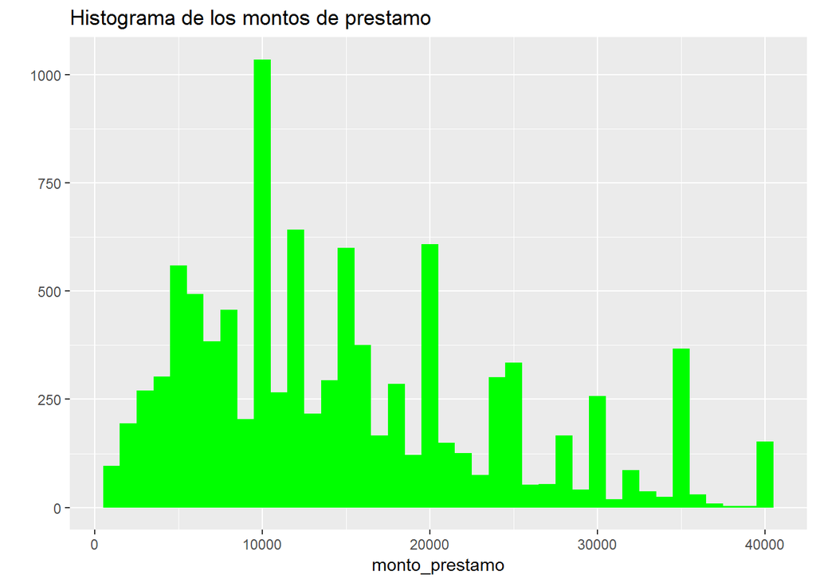

```r
# Realizamos una gráfica de los montos de préstamo
library(ggplot2)
qplot(data_fin$monto_prestamo,
    geom="histogram",
      binwidth = 1000,
     main = "Histograma de los montos de prestamo",
      xlab = "monto_prestamo",
      fill=I("green"))
```

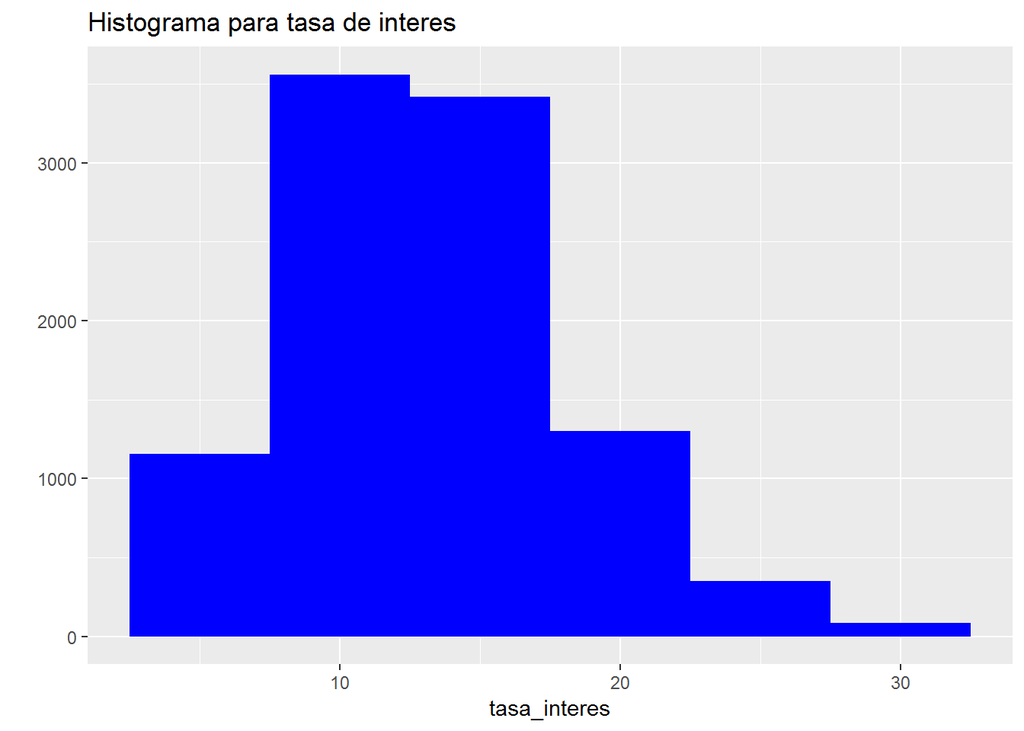

```r
# Realizamos una gráfica de las tasas de interés de los préstamos
qplot(data_fin$tasa_interes,
      geom="histogram",
      binwidth = 5,
      main = "Histograma para tasa de interes",
      xlab = "tasa_interes",
      fill=I("blue"))
```

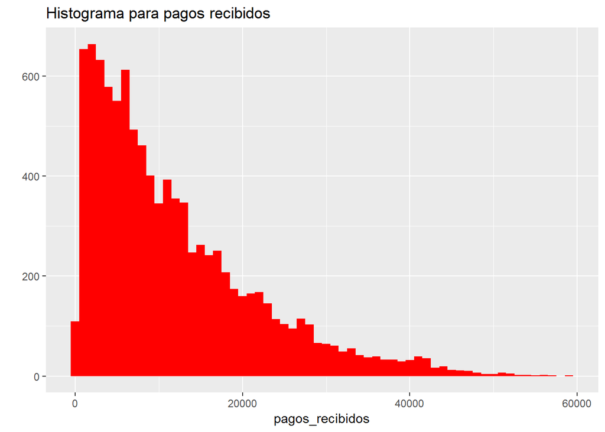

```r
# Realizamos una gráfica de los pagos recibidos
qplot(data_fin$pagos_recib,
      geom="histogram",
      binwidth = 1000,
      main = "Histograma para pagos recibidos",
      xlab = "pagos_recibidos",
      fill=I("red"))
```

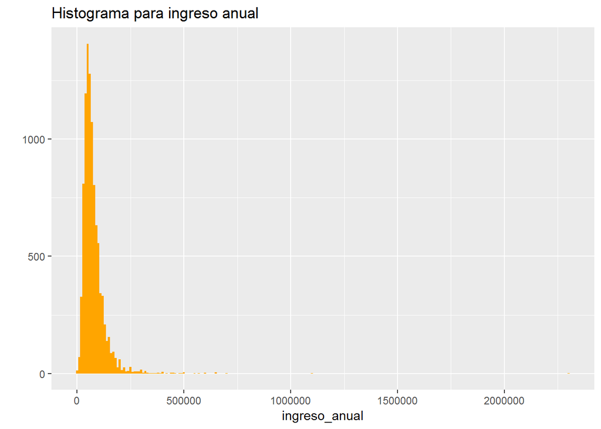

```r
# Realizamos una gráfica de los ingresos anuales
qplot(data_fin$ingreso_anual,
      geom="histogram",
      binwidth = 10000,
      main = "Histograma para ingreso anual",
      xlab = "ingreso_anual",
      fill=I("orange"))
```

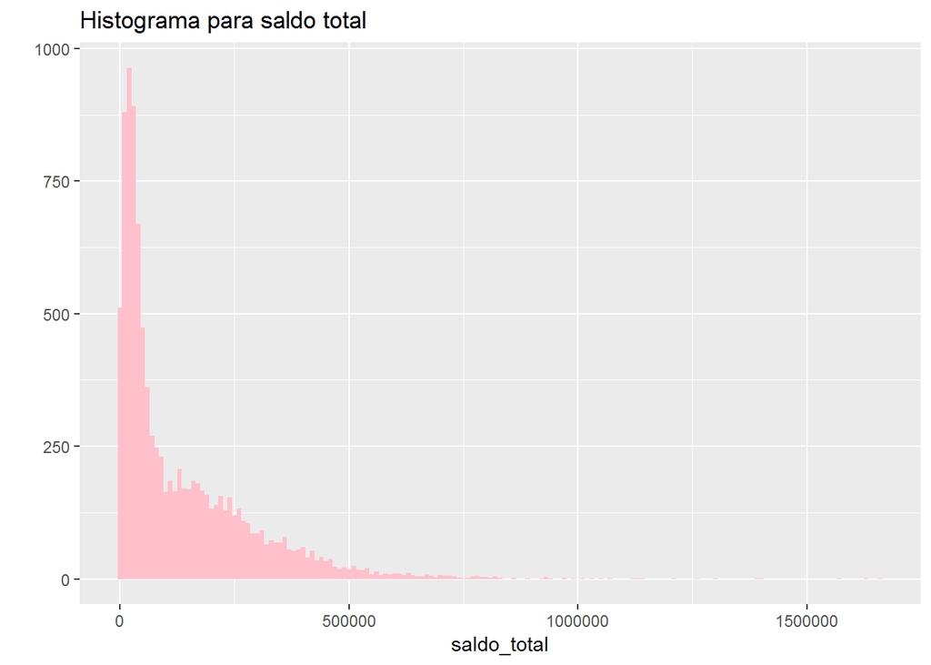

```r
# Realizamos una gráfica del saldo total
qplot(data_fin$saldo_total,
      geom="histogram",
      binwidth = 10000,
      main = "Histograma para saldo total",
      xlab = "saldo_total",
      fill=I("pink"))
```

Podemos llegar a algunas conclusiones gracias a los histogramas anteriores: 1. Los préstamos oscilan entre los 1000 y los 40000 2. La mayor parte de las tasas de interés, están entre el 8% y el 22% 3. La mayoría de los pagos recibidos está por debajo de los 10,000 4. Existen valores muy diferentes en el ingreso anual (min=0 y máx=2300000), por lo que podríamos estandarizar la variable o realizar un análisis adicional.

Convertiremos la variable de ingreso anual, en el logaritmo base 10 y le llamaremos log_ingreso_anual, para ver si la distribución de los valores es mejor. Después graficamos los resultados.

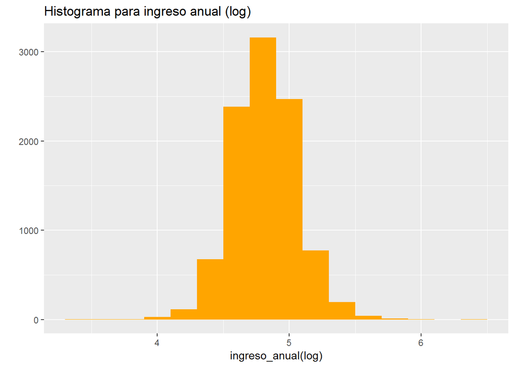

```r
data_fin$log_ingreso_anual<-log10(data_fin$ingreso_anual)
# Realizamos nuevamente la gráfica de los ingresos anuales, transformados
qplot(data_fin$log_ingreso_anual,
      geom="histogram",
      binwidth = .2,
      main = "Histograma para ingreso anual (log)",
      xlab = "ingreso_anual(log)",
      fill=I("orange"))
```

Al convertir la variable se muestra una nota, de que 9 valores fueron eliminados, debido a que salen del rango.

De cualquier forma, utilizaremos esta variable transformada para continuar con el análisis, ya que tiene una mejor distribución que la variable original. Solamente hay que tener en cuenta que una vez realizado el análisis se tiene que tranformar inversamente la variable para que tenga sentido el resultado final.

Ahora realizaremos el análisis de las variables categóricas.

```r
attach(data_fin)
table(plazo)
```

```
## plazo
## 36 months 60 months
##      7025      2841
```

```r
table(estatus_vivienda)
```

```
## estatus_vivienda
##      ANY MORTGAGE    OTHER      OWN     RENT
##        3     4791        3     1136     3933
```

```r
table(estatus_verif_ingreso)
```

```
## estatus_verif_ingreso
##    Not Verified Source Verified        Verified
##            3276            3898            2692
```

```r
table(estatus_prestamo)
```

```
## estatus_prestamo
##                                         Charged Off
##                                                1117
##                                             Current
##                                                4104
## Does not meet the credit policy. Status:Charged Off
##                                                   1
##  Does not meet the credit policy. Status:Fully Paid
##                                                   9
##                                          Fully Paid
##                                                4465
##                                     In Grace Period
##                                                  49
##                                   Late (16-30 days)
##                                                  17
##                                  Late (31-120 days)
##                                                 104
```

Podemos ver con estas tablas las siguientes afirmaciones: 1. La mayoría de los préstamos son a 36 meses de plazo 2. Los estatus más comunes en el caso de la vivienda son: MORTGAGE y RENT 3. En el caso del estatus de la verificación del ingreso, la distribución en las 3 clases es muy parecida 4. Los estatus del préstamo más comunes son: Current y Fully Paid. 5. Hay muy pocos préstamos que están retrasados (121)

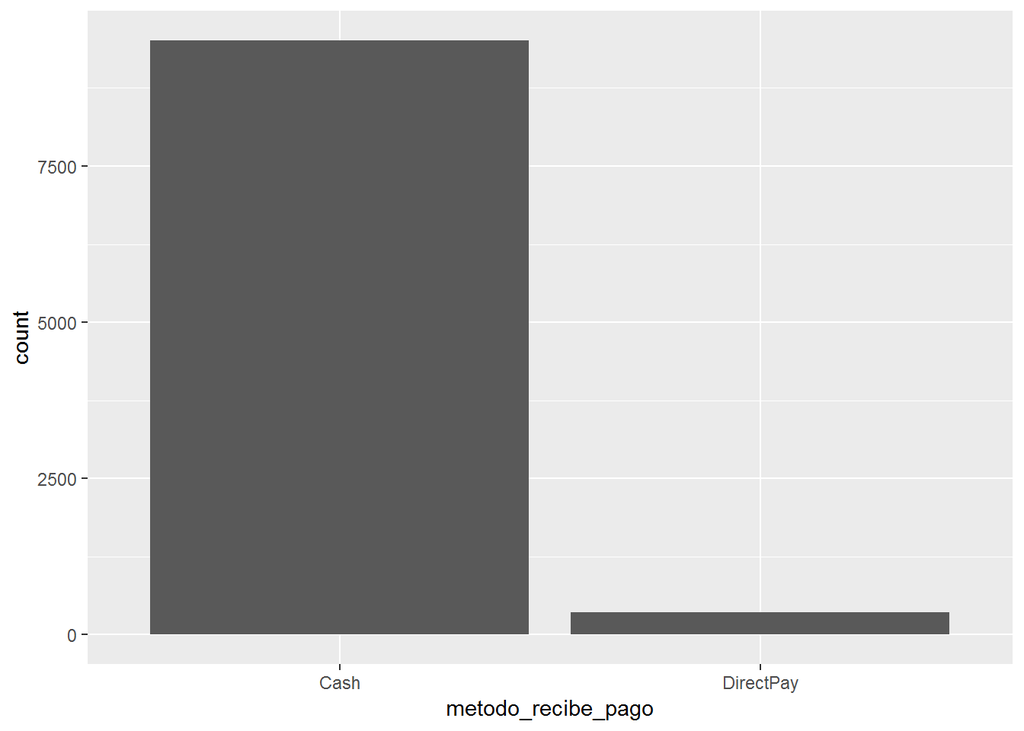

```r
ggplot(data_fin,aes(x=metodo_recibe_pago,fill=monto_prestamo))+geom_bar()
```

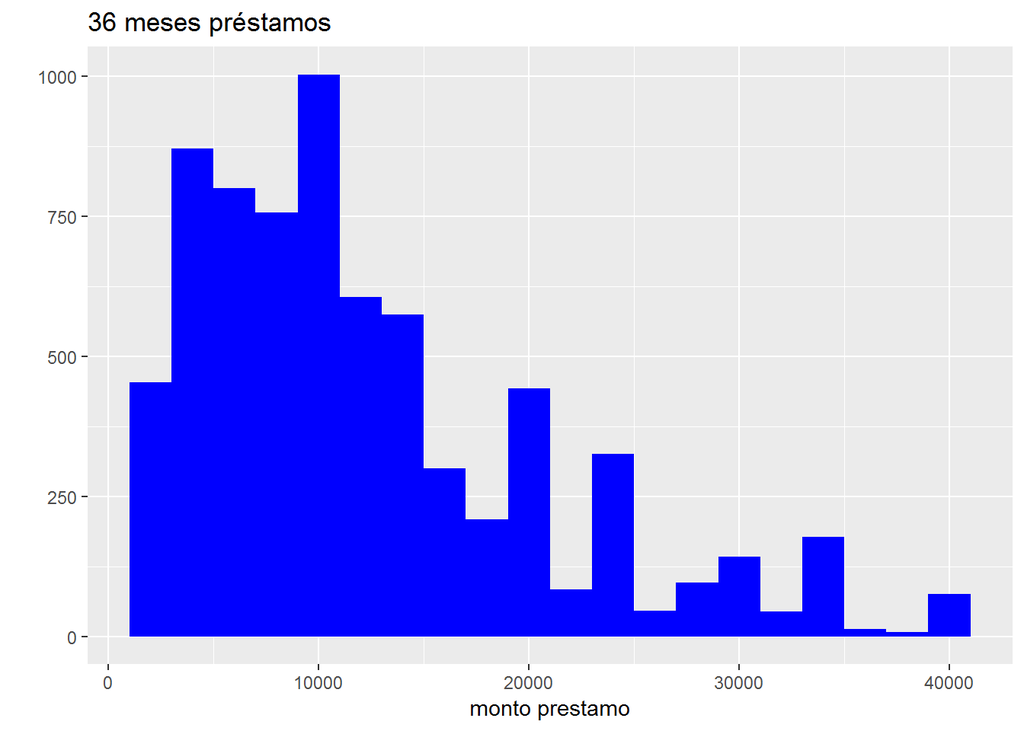

```r
datos_plazo1<-subset(data_fin,plazo=="36 months")
datos_plazo2<-subset(data_fin,plazo=="60 months")
#realizamos las graficas por separado para compararlos
qplot(datos_plazo1$monto_prestamo,
      geom="histogram",
      binwidth = 2000,
      main = "36 meses préstamos",
      xlab = "monto prestamo",
      fill=I("blue"))
```

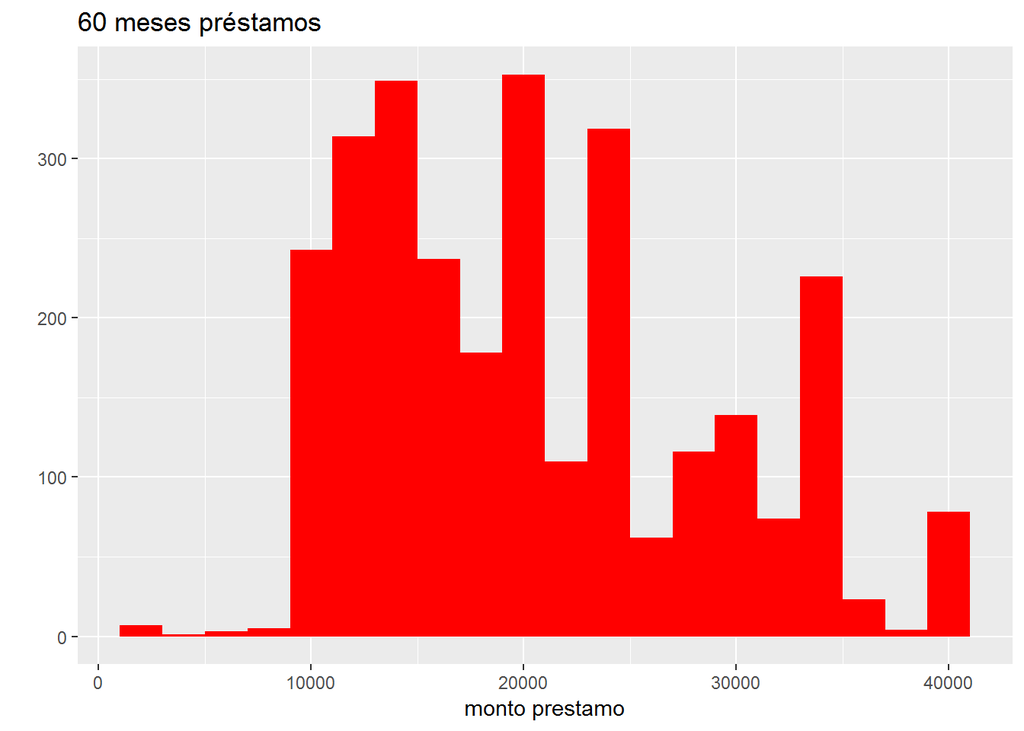

```r
qplot(datos_plazo2$monto_prestamo,
      geom="histogram",
      binwidth = 2000,
      main = "60 meses préstamos",
      xlab = "monto prestamo",
      fill=I("red"))
```

En la gráfica de los 36 meses podemos notar, que los montos de los préstamos son más pequeños.

Se podrían realizar todo tipo de graficas para visualizar la forma de los datos y obtener más información acerca de los datos, sin embargo con base en este análisis inicial podemos empezar a realizar algunas suposiciones de la base de datos que tenemos. Ya se comentaron algunas a lo largo de la explicación anterior, estos análisis son muy importantes debido a que nos dan luz sobre el tipo de modelos que se pueden realizar para las distintas preguntas que queremos contestar.

Realizaremos un análisis de correlación entre las variables monto_prestamo y la tasa de interés.

```r
#install.packages("PerformanceAnalytics")
library(PerformanceAnalytics)
```

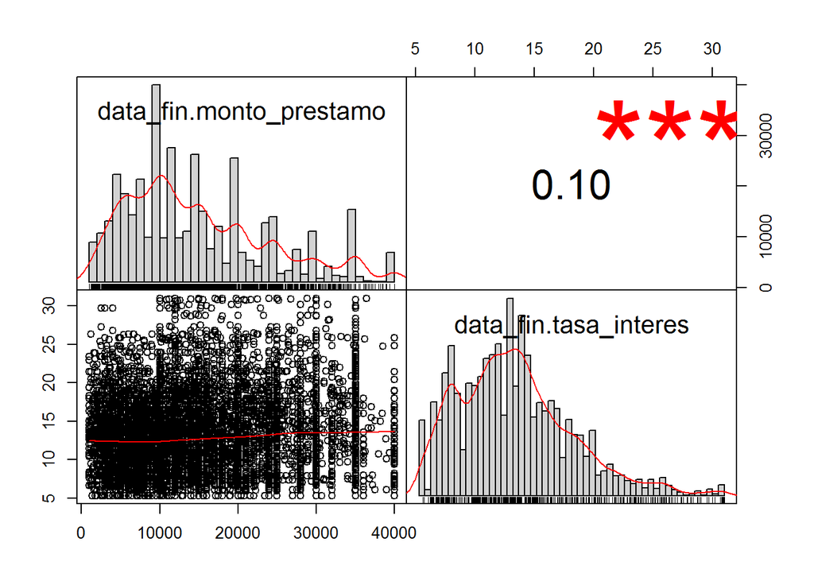

```r
# Realizamos un análisis de correlación entre las variables
dat1 <- data.frame(data_fin$monto_prestamo, data_fin$tasa_interes)
chart.Correlation(dat1)
```

También realizaremos un análisis de correlación entre las variables monto_prestamo y pagos_recib

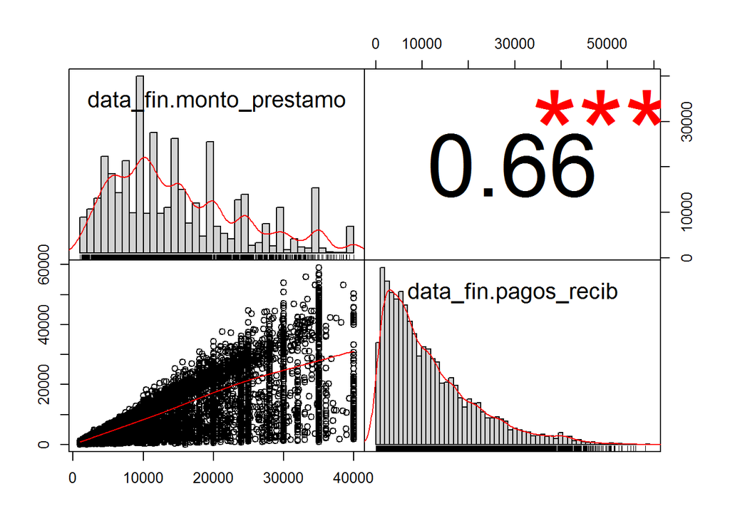

```r
library(PerformanceAnalytics)
# Realizamos un análisis de correlación entre las variables
dat1 <- data.frame(data_fin$monto_prestamo, data_fin$pagos_recib)
chart.Correlation(dat1)
```

A continuación compararemos si el monto del préstamo es mayor cuando una persona vive en TN o en MN. Por esta razón crearemos 2 muestras, las de las personas que viven en TN y la de las personas que viven en MN.

```r
data_fin.TN.montos <-
data_fin[data_fin$estado_vive == "TN",]$monto_prestamo
data_fin.MN.montos <-
data_fin[data_fin$estado_vive == "MN",]$monto_prestamo
```

Así planteamos el contraste de hipótesis de las dos muestras sobre la diferencia de medias.

```r
t.test(data_fin.TN.montos, data_fin.MN.montos,
alternative = "less")
```

```
##
##  Welch Two Sample t-test
##
## data:  data_fin.TN.montos and data_fin.MN.montos
## t = -0.5286, df = 317.68, p-value = 0.2987
## alternative hypothesis: true difference in means is less than 0
## 95 percent confidence interval:
##      -Inf 1088.204
## sample estimates:
## mean of x mean of y
##  13642.69  14155.80
```

Por último, realizaremos algunos modelos de regresión lineal con las variables que hemos ido visualizando en el trabajo para poder identificar si es posible predecir el monto del prestamo con dichas variables.

```r
# Regresores numericos
interes = data_fin$tasa_interes
pagos = data_fin$pagos_recib
# Regresores cualitativos
plazop = data_fin$plazo
metodop = data_fin$metodo_recibe_pago
# Variable a predecir
monto = data_fin$monto_prestamo
# Generación de dos modelos
modelo1 <- lm(monto ~ pagos + plazop, data = data_fin)
modelo2 <- lm(monto ~ interes + pagos + plazop +
metodop, data = data_fin)
```

Calculamos el coeficente de determinación para medir la bondad de loos dos modelos realizados:

```r
tabla.coeficientes <- matrix(c(1, summary(modelo1)$r.squared,
2, summary(modelo2)$r.squared),
ncol = 2, byrow = TRUE)
colnames(tabla.coeficientes) <- c("Modelo", "R^2")
tabla.coeficientes
```

```
##      Modelo       R^2
## [1,]      1 0.5061911
## [2,]      2 0.5237208
```

Ambos coeficientes son bajos para este tipo de pruebas, sin embargo de elegir uno de los modelos deberíamos elegir el segundo, ya que tiene el mejor coeficiente.